# PS0002 Tut 10 Notes

Caleb Tay (caleb.tay@ntu.edu.sg)

28 Mar 2025

# Clustering

Clustering is the final machine learning algorithm in this course. In contrast to the previous types of machine learning, clustering is an *unsupervised learning method*. In previous weeks, all the models we trained had a target: to *predict* an outcome variable based on some predictors.

In clustering, however, we have no such target - we aim to understand *how data may be grouped* in a dataset. For example, you may be trying to see how to group the `iris` dataset, i.e. how many distinct groups there are. While the dataset description says there are 3 species, pretend that we don’t know that. How can we identify how many species there may be? How can we group the data based on just the measurements available?

For this tutorial, we will use 2 clustering algorithms, k-means clustering and hierarchical clustering, to answer this question. These clustering algorithms *rely on a notion of distance*, and so the scales of the predictors have an effect on the final outcome.

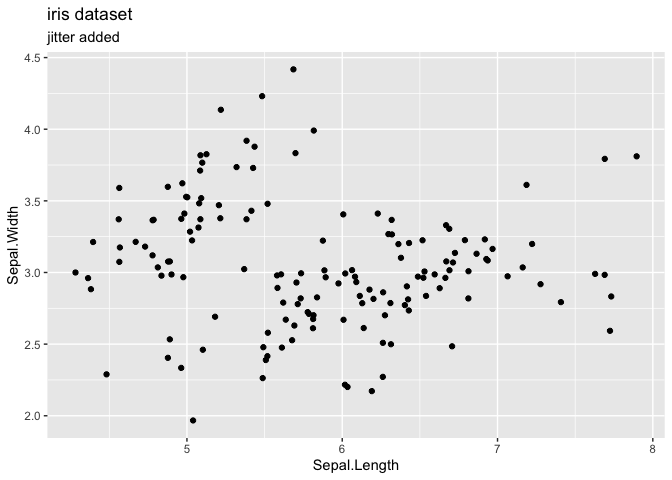

# k-means clustering

In k-means clustering, we will specify how many clusters $k$ there are in our dataset, and perform the following steps to determine which cluster each observation belongs to.

1. Assign each observation a random cluster $1, \dots, k$.
2. Calculate the *mean* point of each cluster.
3. Assign each observation the cluster mean that it is closest to.
4. Repeat steps 2 and 3 until the clusters converge (do not change), or until max number of iterations is reached.

It is important to have a maximum number of iterations, as it is possible that the clustering algorithm may simply alternate between two states and never converge.

## `USArrests` dataset

The `USArrests` dataset found in base R contains statistics for arrests in each U.S.A. state in 1973. We can see the rates of arrest for some crimes per 100,000 people, as well as the urban population of each state. The scales of each predictor are extremely different, and to account for that, we must *normalise* the data. Here, we will use the `scale()` function, which centers the mean to 0 and scales the standard deviation of each predictor to 1.

We will use the scaled dataset for our clustering.

```r
data(USArrests)
str(USArrests)
```

```
## 'data.frame':    50 obs. of  4 variables:
##  $ Murder  : num  13.2 10 8.1 8.8 9 7.9 3.3 5.9 15.4 17.4 ...
##  $ Assault : int  236 263 294 190 276 204 110 238 335 211 ...
##  $ UrbanPop: int  58 48 80 50 91 78 77 72 80 60 ...
##  $ Rape    : num  21.2 44.5 31 19.5 40.6 38.7 11.1 15.8 31.9 25.8 ...
```

```r
arrests.nor <- scale(USArrests)
summary(arrests.nor)
```

```
##      Murder           Assault           UrbanPop             Rape
##  Min.   :-1.6044   Min.   :-1.5090   Min.   :-2.31714   Min.   :-1.4874
##  1st Qu.:-0.8525   1st Qu.:-0.7411   1st Qu.:-0.76271   1st Qu.:-0.6574
##  Median :-0.1235   Median :-0.1411   Median : 0.03178   Median :-0.1209
##  Mean   : 0.0000   Mean   : 0.0000   Mean   : 0.00000   Mean   : 0.0000
##  3rd Qu.: 0.7949   3rd Qu.: 0.9388   3rd Qu.: 0.84354   3rd Qu.: 0.5277
##  Max.   : 2.2069   Max.   : 1.9948   Max.   : 1.75892   Max.   : 2.6444
```

## Extra: standardisation a.k.a. z-scoring

This scaling and shifting of a dataset to have a mean of 0 and standard deviation of 1 is also known as *standardisation* or *z-scoring*, named after the standard normal variable with mean 0 and variance 1, $\mathrm{N}(0, 1)$, also commonly referred to as $\mathrm{Z}$. This is just another way of normalising the dataset to make its features comparable. The `scale()` function applies this transformation, which is defined as:

$$x_{\textrm{scaled}} = \frac{x - \mathrm{mean}(x)}{\mathrm{sd}(x)}$$

## Performing k-means clustering

In R, we will use the `kmeans()` function in base R to perform k-means clustering. In addition to the dataset, we **must** specify the number of clusters $k$ through the `centers` parameter. Optionally, we can also specify the number of initial states `nstart` and maximum number of iterations `iter.max`.

Once the k-means clustering algorithm converges or it reaches the maximum number of iterations, it returns the resulting clusters, as well as some statistics on the clusters, namely the *within-cluster sum of squares* and *between-cluster sum of squares*. The definition of each is not important to the course, but roughly:

- the *within-cluster sum of squares* of **each cluster** describes how spread the observations in each cluster are (compared to the cluster center);
- the *between-cluster sum of squares* describes how spread the **cluster centers** are from each other.

```r
set.seed(1337)
kmeans.2 <- kmeans(arrests.nor, centers = 2, nstart = 25, iter.max = 10)
kmeans.2
```

```
## K-means clustering with 2 clusters of sizes 20, 30
##
## Cluster means:
##      Murder    Assault   UrbanPop       Rape
## 1  1.004934  1.0138274  0.1975853  0.8469650
## 2 -0.669956 -0.6758849 -0.1317235 -0.5646433
##
## Clustering vector:
##        Alabama         Alaska        Arizona       Arkansas     California
##              1              1              1              2              1
##       Colorado    Connecticut       Delaware        Florida        Georgia
##              1              2              2              1              1
##         Hawaii          Idaho       Illinois        Indiana           Iowa
##              2              2              1              2              2
##         Kansas       Kentucky      Louisiana          Maine       Maryland
##              2              2              1              2              1
##  Massachusetts       Michigan      Minnesota    Mississippi       Missouri
##              2              1              2              1              1
##        Montana       Nebraska         Nevada  New Hampshire     New Jersey
##              2              2              1              2              2
##     New Mexico       New York North Carolina   North Dakota           Ohio
##              1              1              1              2              2
##       Oklahoma         Oregon   Pennsylvania   Rhode Island South Carolina
##              2              2              2              2              1
##   South Dakota      Tennessee          Texas           Utah        Vermont
##              2              1              1              2              2
##       Virginia     Washington  West Virginia      Wisconsin        Wyoming
##              2              2              2              2              2
##
## Within cluster sum of squares by cluster:
## [1] 46.74796 56.11445
##  (between_SS / total_SS =  47.5 %)
##
## Available components:
##
## [1] "cluster"      "centers"      "totss"        "withinss"     "tot.withinss"
## [6] "betweenss"    "size"         "iter"         "ifault"
```

## Selection of $k$

The above was done for only a single value of $k$ - and so we will have to test *multiple* values of $k$. To determine the optimal $k$, we will look at the *total within-cluster sum of squares* to *minimise the variation* within each cluster, i.e. each point within the cluster is most similar to each other. As the number of clusters increases, the within-cluster variation naturally decreases (at the limit, when number of clusters = number of observations, the within-cluster variation is 0, since each cluster only has 1 point).

So, to choose an appropriate value of $k$, we will use the ‘elbow method’, in which we choose the value of $k$ that has a ‘bend’ in the plotted curve. The ‘bend’ occurs at $k = 4$, so we use that as the final number of clusters for the dataset.

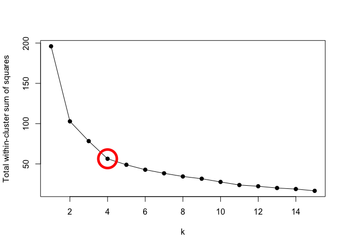

```r
wcss <- function(k) {
  set.seed(100)
  kmeans(arrests.nor, k, nstart = 10)$tot.withinss
}

wcss_k <- sapply(1:15, wcss)

k = 4

plot(wcss_k, type="o", pch=19, xlab="k", ylab="Total within-cluster sum of squares")
points(x=k, y=wcss_k[k], pch=1, cex=5, col="red", lwd=5)
```

### Extremely optional: further criteria on selection of $k$

We may also consider the differences between the total within-cluster sum of squares, which can be calculated with `diff()`. The second difference shows where a good choice of $k$ is, indicated by a sudden spike and then decrease. The theory for this is not complicated, but does take some thinking through.

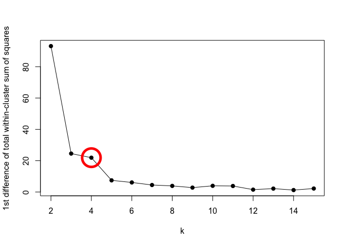

```r
plot(2:15, -diff(wcss_k), type="o", pch=19, xlab="k", ylab="1st difference of total within-cluster sum of squares")
points(x=k, y=-diff(wcss_k)[k-1], pch=1, cex=5, col="red", lwd=5)
```

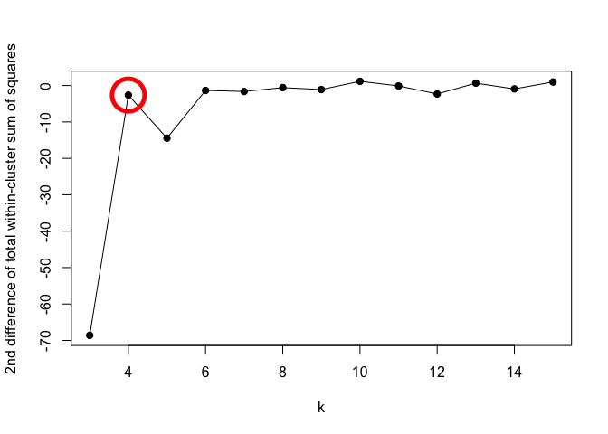

```r
plot(3:15, -diff(wcss_k, differences=2), type="o", pch=19, xlab="k", ylab="2nd difference of total within-cluster sum of squares")
points(x=k, y=-diff(wcss_k, differences=2)[k-2], pch=1, cex=5, col="red", lwd=5)
```

## Final k-means clustering

Looking at the final clustering result with $k = 4$, we can see the *scaled* cluster centers as well as to which cluster each state belongs to. The ordering of the clusters (the cluster numbers) may be different, though the states are clustered the same. The scaled centers do not represent any real-world statistic, so to truly understand what these clusters represent, we have to look at the *unscaled* cluster centers.

```r
set.seed(100)
kmeans.final <- kmeans(arrests.nor, 4)
kmeans.final
```

```
## K-means clustering with 4 clusters of sizes 8, 16, 13, 13
##
## Cluster means:
##       Murder    Assault   UrbanPop        Rape
## 1  1.4118898  0.8743346 -0.8145211  0.01927104
## 2 -0.4894375 -0.3826001  0.5758298 -0.26165379
## 3 -0.9615407 -1.1066010 -0.9301069 -0.96676331
## 4  0.6950701  1.0394414  0.7226370  1.27693964
##
## Clustering vector:
##        Alabama         Alaska        Arizona       Arkansas     California
##              1              4              4              1              4
##       Colorado    Connecticut       Delaware        Florida        Georgia
##              4              2              2              4              1
##         Hawaii          Idaho       Illinois        Indiana           Iowa
##              2              3              4              2              3
##         Kansas       Kentucky      Louisiana          Maine       Maryland
##              2              3              1              3              4
##  Massachusetts       Michigan      Minnesota    Mississippi       Missouri
##              2              4              3              1              4
##        Montana       Nebraska         Nevada  New Hampshire     New Jersey
##              3              3              4              3              2
##     New Mexico       New York North Carolina   North Dakota           Ohio
##              4              4              1              3              2
##       Oklahoma         Oregon   Pennsylvania   Rhode Island South Carolina
##              2              2              2              2              1
##   South Dakota      Tennessee          Texas           Utah        Vermont
##              3              1              4              2              3
##       Virginia     Washington  West Virginia      Wisconsin        Wyoming
##              2              2              3              3              2
##
## Within cluster sum of squares by cluster:
## [1]  8.316061 16.212213 11.952463 19.922437
##  (between_SS / total_SS =  71.2 %)
##
## Available components:
##
## [1] "cluster"      "centers"      "totss"        "withinss"     "tot.withinss"
## [6] "betweenss"    "size"         "iter"         "ifault"
```

The calculation of the cluster mean is achieved by simply adding the cluster information to the original, unscaled data, and calculating the cluster means from there. In the notes, `summarise_all()` is used. I chose to use `summarise()` with `across()` to allow the addition of an additional statistic, the number of states in the cluster.

In the resulting clustering, we can see that clusters 2 and 3 have a lower murder and assault rate, and differ in their urban population. We may choose to focus on these two clusters for further study in the real world.

```r
USArrests %>% mutate(Cluster=kmeans.final$cluster) %>%
  group_by(Cluster) %>% summarise(across(everything(), mean), count = n())
```

```
## # A tibble: 4 × 6
##   Cluster Murder Assault UrbanPop  Rape count
##     <int>  <dbl>   <dbl>    <dbl> <dbl> <int>
## 1       1  13.9    244.      53.8  21.4     8
## 2       2   5.66   139.      73.9  18.8    16
## 3       3   3.6     78.5     52.1  12.2    13
## 4       4  10.8    257.      76    33.2    13
```

# Hierarchical clustering

Hierarchical clustering is more of a *bottom-up* approach, and is described as an agglomerative clustering method, where we take every observation to be a cluster by itself, and procedurally combine the closest clusters, until the whole dataset is a single cluster. The method by which the clusters are combined may be defined differently: for example, we may choose to combine the 2 clusters whose means are closest together. Alternatively, we may also choose to measure the minimum or maximum distance between each cluster (based on the observations in each cluster) and combine the 2 clusters with the smallest minimum or maximum distance.

## `USArrests` dataset

Again, we will see how hierarchical clustering performs on the `USArrests` dataset. To perform a hierarchical clustering, we use the `hclust()` function in base R, which requires a *distance matrix*, computed with the `dist()` function in base R.

## Distance matrices with `dist()`

A **distance matrix** is a square matrix that describes the *distance* from every single point to every other. If we have $n$ observations $x_1, \dots, x_n$, then the $(i, j)$th entry in the distance matrix describes how far $x_i$ is from $x_j$. Distance is symmetric (the distance from $x_i$ to $x_j$ is the same as the distance from $x_j$ to $x_i$), so the distance matrix is also symmetric about the diagonal.

Also, there are multiple ways to calculate a distance - again, we will rely on the *Euclidean measure*, which is the natural notion of distance.

## Performing hierarchical clustering

We first compute the distance matrix with `dist()`. The default argument for the `method` parameter is `"euclidean"`. Once the distance matrix is computed, we can pass it in to `hclust()`, and optionally specify the `method` of how the clusters are combined. By default, `method="complete"`.

With `method="complete"`, the two clusters with the smallest maximum distance between points in the cluster are combined, `"average"` combines the closest cluster centers, and `"single"` combines the two clusters with the smallest minimum distance between points in the cluster.

```r
distance <- dist(arrests.nor, method = "euclidean")
h.clust <- hclust(distance, method = "complete")
```

## Visualising hierarchical clustering with a dendrogram

Once the clustering is complete, we can visualise the results with a **dendrogram**. The height on the y-axis indicates the distance at which each cluster was joined. To determine a suitable number of clusters, we can see the point at which the jump in height significantly increases - in this case, when they are clustered from 4 to 3 (and then quickly to 2) clusters.

We can draw a rectangle around the clusters in the dendrogram with `rect.hclust()`, specifying the number of clusters `k`, and optionally the colours to use with `border`. In this case, `k = 4`, and we choose four colours with `border = 2:5`.

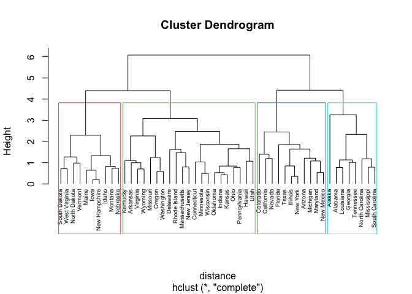

```r
# cex - text size, hang - position of labels
plot(h.clust, cex = 0.6, hang = -1)

# k - number of clusters, border - colours to use
rect.hclust(h.clust, k = 4, border = 2:5)
```

## Extra: getting the cluster values

To get the final clustering results, we can use the `cutree()` function with the output of `hclust()`, specifying how many clusters we want. You can then process the data in a similar way to get the unscaled data means.

```r
h.clust.4 <- cutree(h.clust, 4)
h.clust.4
```

```
##        Alabama         Alaska        Arizona       Arkansas     California
##              1              1              2              3              2
##       Colorado    Connecticut       Delaware        Florida        Georgia
##              2              3              3              2              1
##         Hawaii          Idaho       Illinois        Indiana           Iowa
##              3              4              2              3              4
##         Kansas       Kentucky      Louisiana          Maine       Maryland
##              3              3              1              4              2
##  Massachusetts       Michigan      Minnesota    Mississippi       Missouri
##              3              2              3              1              3
##        Montana       Nebraska         Nevada  New Hampshire     New Jersey
##              4              4              2              4              3
##     New Mexico       New York North Carolina   North Dakota           Ohio
##              2              2              1              4              3
##       Oklahoma         Oregon   Pennsylvania   Rhode Island South Carolina
##              3              3              3              3              1
##   South Dakota      Tennessee          Texas           Utah        Vermont
##              4              1              2              3              4
##       Virginia     Washington  West Virginia      Wisconsin        Wyoming
##              3              3              4              3              3
```

# Results of clustering

Once the clustering is complete, we can use the clustering to then furhter understand the data. For example, we may choose to focus on the cluster of states which have a higher rate of arrests for murder and assault, trying to identify if there may be any causal link between them. This process is separate from the data analysis.

Note that each clustering method, while largely the same, still had slight differences between them.

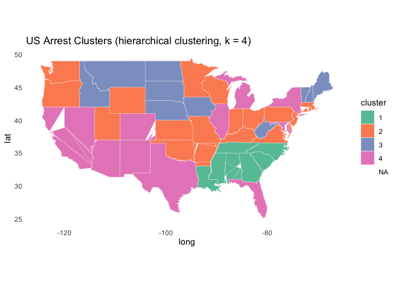

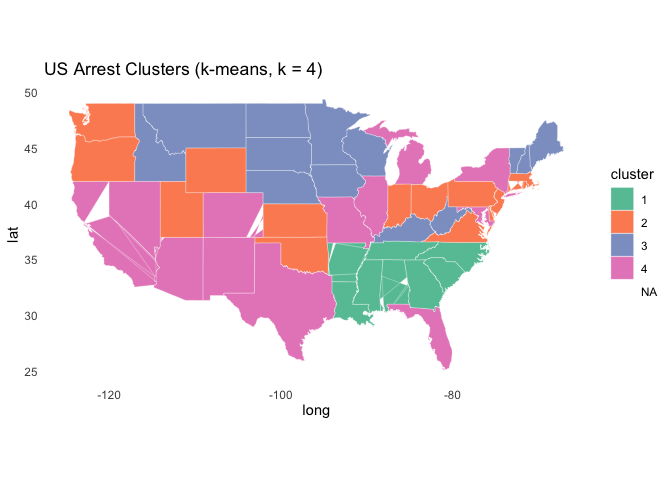